# AniSpace vignettes

Hector Marina

2025-09-01

[figure not shown]

# Examples

## Introduction

This tutorial provides an overview of how to read and manipulate location data using the AniSpace R package. During the tutorial, we will examine a commercial dairy farm in Sweden. The farm has installed an ultra-wideband Real-Time Location System (RTLS) that provides the location of all the cows. Lactating cows have been fitted with tags attached to their collars. By using the cows’ position information, we can investigate their daily behaviour, how they utilise the area, and their spatial interactions with their peers.

1. Install AniSpace package  
   1.1. Position information  
   1.2. Animal information  
   1.3. Farm information
2. Descriptive statistics  
   2.1. Position stats  
   2.2. Area stats  
   2.3. Accuracy of the system
3. Filtering data
4. Interpolation
5. Movement analysis
6. Social networks

### Install AniSpace package

You can install the development version of `AniSpace` from GitHub using `remotes`:

```r
# install.packages("remotes")
remotes::install_github("Hector-Marina/AniSpace")
```

Lets load the R package into our environment and the example data from the Swedish farm:

```r
library("AniSpace")
data("cows")
```

## Position information

Position data was collected from a Swedish commercial dairy farm. This farm housed around 210 lactating dairy cows (Holstein, Red Dairy Cattle, and Crossbred) in a non-insulated free-stall barn. The farm is divided into two milking groups, early and late lactation groups, each with a pen area of 14 m × 56 m and 102-103 cubicles, with rubber mattresses and sawdust as bedding material. Further information about the farm can be found in [Hansson et al., 2023](https://doi.org/10.3168/JDS.2022-21915).

```r
head(cows$positions)
```

```
##          Date         Time      ID    x    y
## 3  2020-10-16 1.602806e+12 2417161 2451 7201
## 11 2020-10-16 1.602806e+12 2417195  701 2857
## 22 2020-10-16 1.602806e+12 2225648  941 6227
## 38 2020-10-16 1.602806e+12 2417272 1725 5023
## 42 2020-10-16 1.602806e+12 2417171  821 6173
## 48 2020-10-16 1.602806e+12 2225615 3194 8050
```

For efficiency purposes, AniSpace, like other packages that handle spatial data, requires a special class. Let’s load this information into a more efficient format using our first `AniSpace` function `load.Space()` :) :

```r
df=load.Space(cows$positions)
```

The AniSpace class contains information about the position of the individuals, but also it has different `slots` prepared for other information related to the animals: - **NIDs**: Vector containing the assigned index of the individuals.  
- **IDs**: Vector containing the identification of the individuals.  
- **Info**: Indexed information about the individuals.  
- **TLim**: Contains information about the temporal range covered by the positions (Index=1s).  
- **TRes*’: Maximum temporal resolution of the positions (e.g. smallest time step).  
- **Pos**: Indexed positions (x,y,z) of the individuals.  
- **Area**: Information about the spatial area available for the individuals (Polygon format).

```r
names(df) # or slotNames(df)
```

```
## [1] "NIDs" "IDs"  "Info" "TLim" "TRes" "Pos"  "Area"
```

### Animal information

```r
head(cows$animals)
```

```
##          Date      ID Parity DIM Breed Disease
## 3  2024-01-01 2203669      2 218     2       1
## 34 2024-01-01 2225426      7 263     1       1
## 35 2024-01-01 2417169      6 156     3       1
## 42 2024-01-01 2225648      2 294     2       1
## 45 2024-01-01 2225588      3 144     2       1
## 54 2024-01-01 2417195      4  77     3       0
```

You can add animal’s information to the `AniSpace` object using the function `load.Info()` :). This function will complete the ‘Info’ slot that we saw earlier:

```r
df=load.Info(df, InfObj=cows$animals)
```

### Farm information

The barn is divided into two sections for milking: an early lactation group on the right and a late lactation group on the left. Cubicles are located in the middle of the barn, with feeding tables along the sides. Below, we can see what the farm blueprint information looks like:  
- *Area*: Area identification code.  
- *x1*: X1 coordinate of vertex  
- *x2*: X2 coordinate of vertex  
- *y1*: Y1 coordinate of vertex  
- *y2*: Y2 coordinate of vertex  
- *Color*: Just to make plots pretty.

```r
head(cows$areas)
```

```
##   Area   x1   x2   y1   y2           Color
## 1    0    0 3340    0 2902           beige
## 2    1    0  630 2902 8738 darkolivegreen2
## 3    2 2733 3340 2902 8738 darkolivegreen2
## 4    3  625 1557 2595 2902     deepskyblue
## 5    4 1798 2724 2595 2902     deepskyblue
## 6    5  630 1134 3583 5619     deepskyblue
```

Thirdly, we will fill in the ‘Area’ slot of our ‘AniSpace’ object using the ‘load.Area()’ function:

```r
df=load.Area(AniObj=df, square2poly(cows$areas))
```

```
## All 19 areas and their coordinates passed validation..
```

```
## - Areas: 0, 1, 2, 3, 4, 5, 6, 7, 8, 9, 10, 11, 12, 13, 14, 15, 16, 17, 18; have been added to the AniSpace object.
```

To check that the data has been loaded correctly, simply write the name of the AniSpace object:

```r
df
```

```
## -------AniSpace: Spatio-temporal object-------
## # Individuals: 20 ( 2203669, 2225414, 2225426, 2225534, 2225549 ,...)
## # Traits: 5 ( Date, Parity, DIM, Breed, Disease )
## # Areas: 19 ( 0, 1, 2, 3, 4 ,...)
## # Positions per ID: mean= 61871.25 ; sd= 19816.81
## % missing positions (Time resolution= 1 sec ): 28.39 %
##   Position bounds: x=c( 0 , 3340 ); y=c( 0 , 8738 )
##   Time span: 1602806400 ( 2020-10-16 ) - 1602892800 ( 2020-10-17 )
##   Durantion: 1.0 day(s)
```

If we want to depict the position of any of our individuals we just need to use the function `plotAniSpace()` and indicate the Numeric identification the individual `NIDs` (1:10) or the TagID (`IDs="2417195"`). For instancel:

## One individual

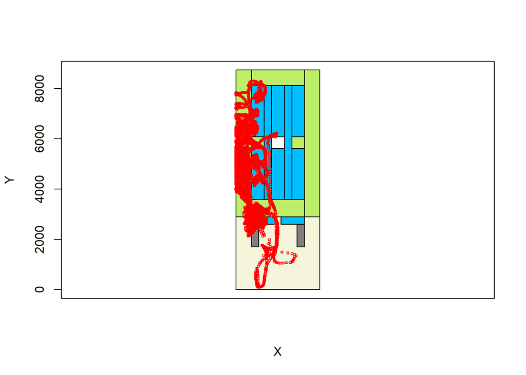

```r
plotAniSpace(df,IDs="2417195")
```

## Two individuals

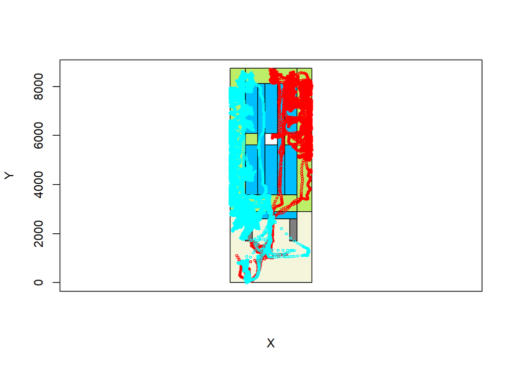

```r
plotAniSpace(df,NIDs=c(12,13))
```

## Three individuals

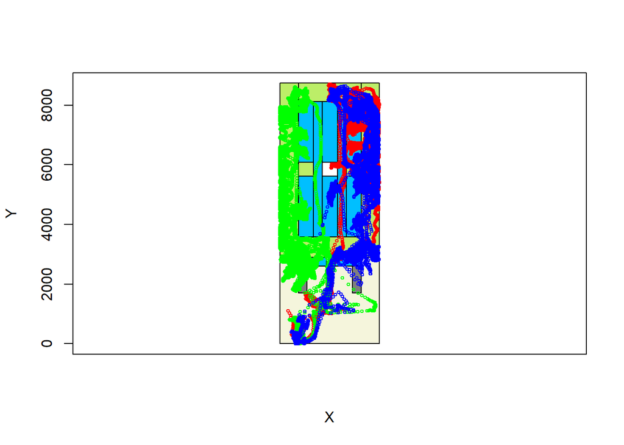

```r
plotAniSpace(df,NIDs=c(12,13,18))
```

## Descriptive statistics

Estimate the statistics of the temporal and spatial information contained within the `AniSpace` object at individual and area levels.

### Position stats

The function `stats.Pos()` reports the minimum and maximum x and y positions per individual, as well as the time range between registered positions, the mean time step or interval between positions, and the mean and maximum speed per individual:

```
## - Global statistics:
##                Average distance walked: 336199.82
##                Average area walked: 8667779.3
##                Average speed: 4.96
```

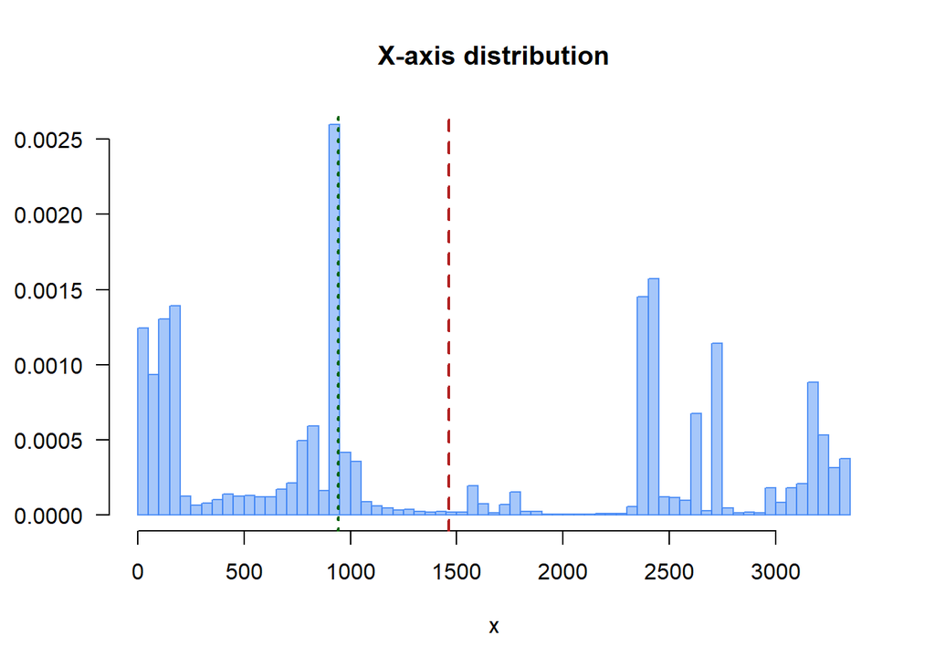

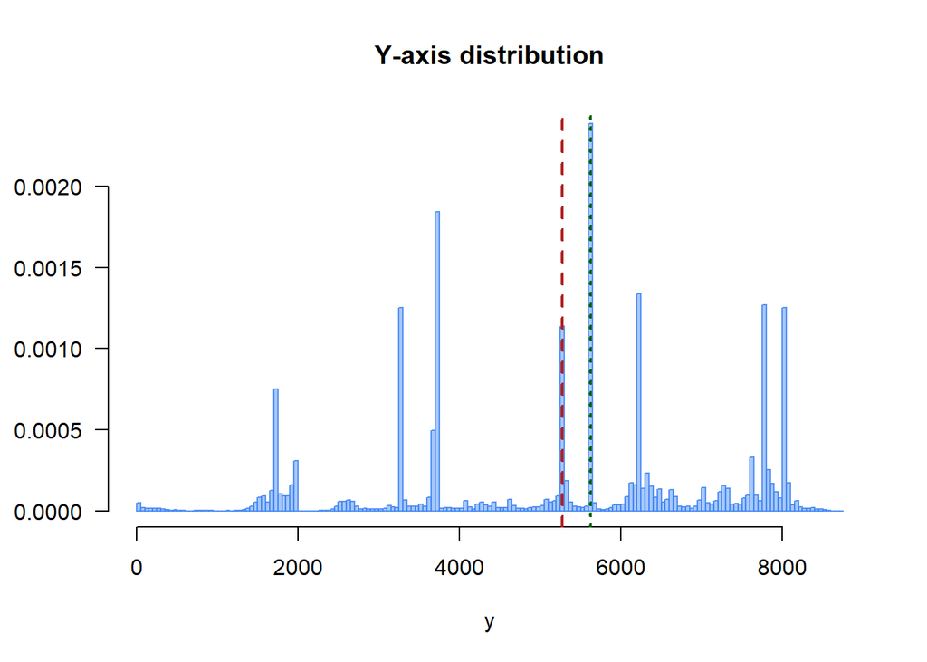

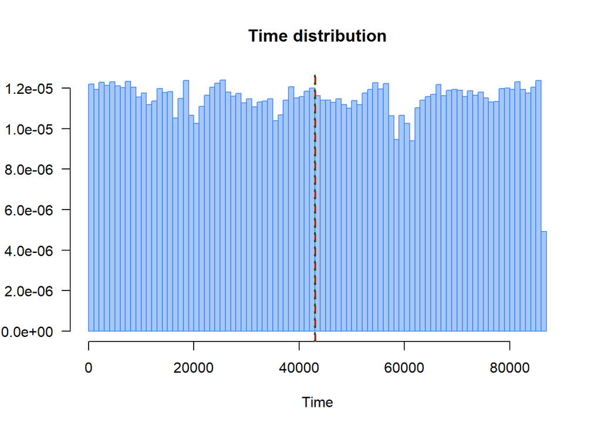

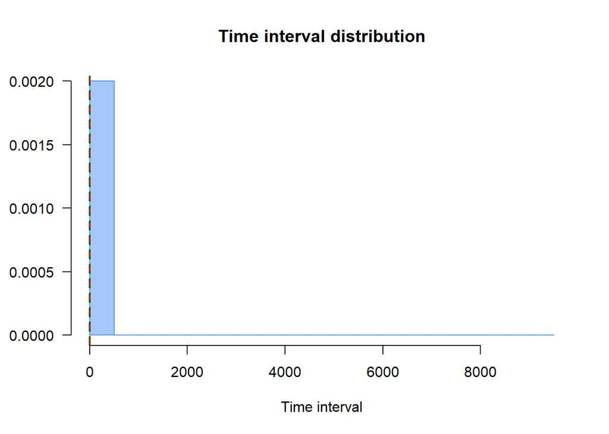

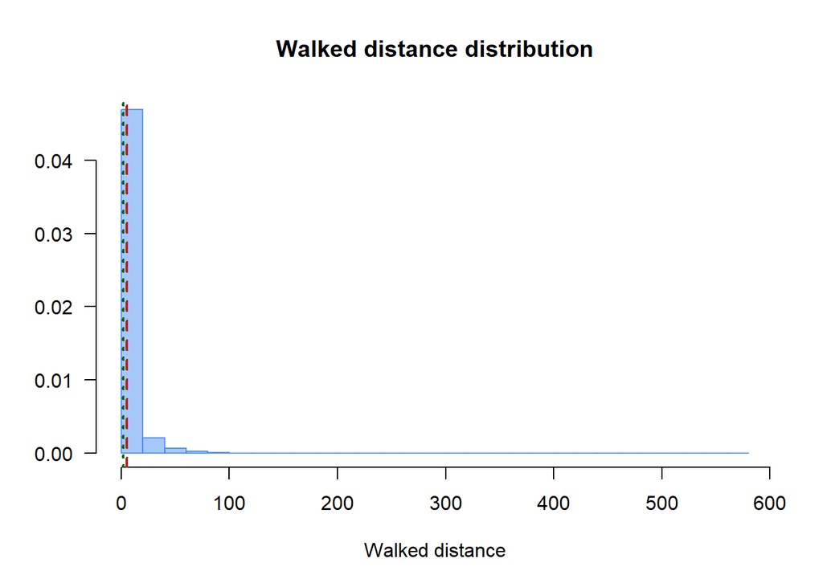

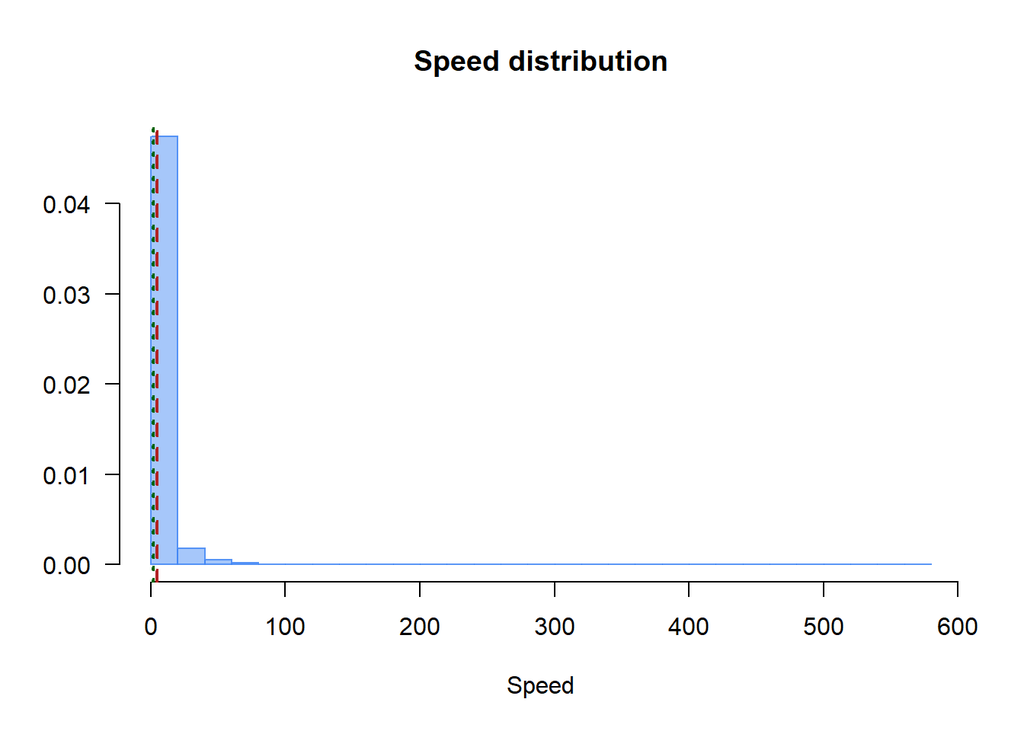

```
##  - See the `obj$graphs` section for a depiction of the parameters' distribution.
##   The dotted red and green lines represent the mean and median, respectively.
```

```r
df.stats.Pos=stats.Pos(AniObj=df, graphs=TRUE)
```

If the argument `graphs` is set to TRUE in the `stats.Pos()` function, the output file is a list. The first object in this list contains the descriptive statistics for each individual, and the second object contains the graphs.

```r
head(df.stats.Pos$DescriptiveStats)
```

```
##   NIDs     IDs npositions min_x max_x min_y max_y Time_range mean_Time_step total_dist
## 1    1 2203669      72122  2721  2933  5450  5881      86399       1.197973   109021.7
## 2    2 2225414      39097  2600  2824  1433  1754      86399       2.209919    51664.1
## 3    3 2225426      75150   518   947  3683  4067      86399       1.149689   113156.2
## 4    4 2225534      74715     0   252  5273  5326      86399       1.156383   222008.3
## 5    5 2225549      76960  2362  2564  5570  5776      86399       1.122650   126846.9
## 6    6 2225588      75720     0   184  7736  7814      86399       1.141035   232595.7
##   total_area mean_speed max_speed
## 1      91372  1.3583592  67.20863
## 2      71904  0.8624443  28.60070
## 3     164736  1.3327009 125.31959
## 4      13356  2.7402534  43.00000
## 5      41612  1.5487556  69.92138
## 6      14352  2.8600604  34.00000
```

### Area stats

The function `stats.Area()` reports the minimum and maximum X and Y positions per area, as well as the area, the total area occupied by the registered positions and the density:

```
## - Global statistics:
##                Average area size: 1581281.32
##                Average occupation: 68094.84
##                Average density: 0.06
```

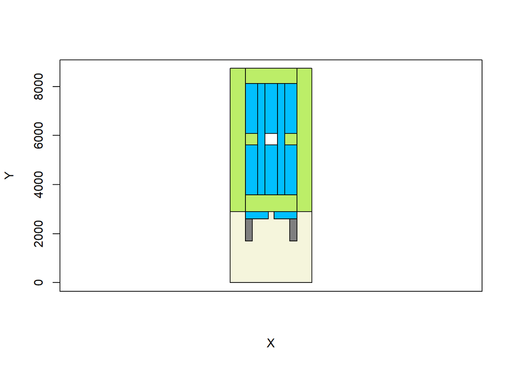

```r
df.stats.Area=stats.Area(AniObj=df, graphs=TRUE)
```

Similarly, If the argument `graphs` is set to TRUE in the `stats.Area()` function the ouput depict the areas contained in the object. In this case, the output object only contains the descriptive statistics for each area.

```r
head(df.stats.Area$DescriptiveStats)
```

```
##   NArea Area mean_x range_x mean_y range_y    area relative_area occupation      density
## 1     1    0 1336.0    3340 1160.8    2902 9692680    0.32261246     162262 0.0167406744
## 2     2    1  252.0     630 5236.4    8738 3676680    0.12237511     344479 0.0936929512
## 3     3    2 2975.8    3340 5236.4    8738 3542452    0.11790745     162220 0.0457931399
## 4     4    3  997.8    1557 2717.8    2902  286124    0.00952339       9836 0.0343767038
## 5     5    4 2168.4    2724 2717.8    2902  284282    0.00946208        177 0.0006226212
## 6     6    5  831.6    1134 4397.4    5619 1026144    0.03415431      98104 0.0956045155
```

### Accuracy of the system

There is different ways of estimating the precision of real-time location systems. Following we will use the method described by [Hansson et al., 2023](https://doi.org/10.3168/JDS.2022-21915), consists of using position stand-still tags in the barn to measure the mean error distance recorded by these devices compared to a fixed position. The information of these tags are included in our `AniSpace` object and recorded daily. Let’s plot ten of them:

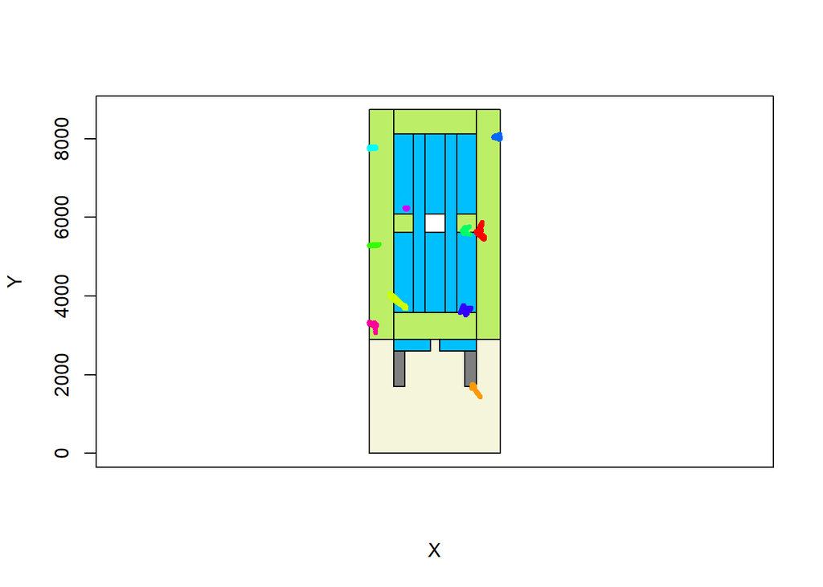

```r
plotAniSpace(df,NIDs=c(1:10))
```

Similarly, to the previous function, if the argument `graphs` is set to TRUE in the `stats.still()` function, the output file is a list. The first object in this list contains the descriptive statistics for each individual, and the second object contains the graphs.

```
## - Average distance error for 0.9 percentile was 27.54
```

```
## - Average distance error for 0.95 percentile was 47.99
```

```
## - Average distance error for 0.99 percentile was 84.46
```

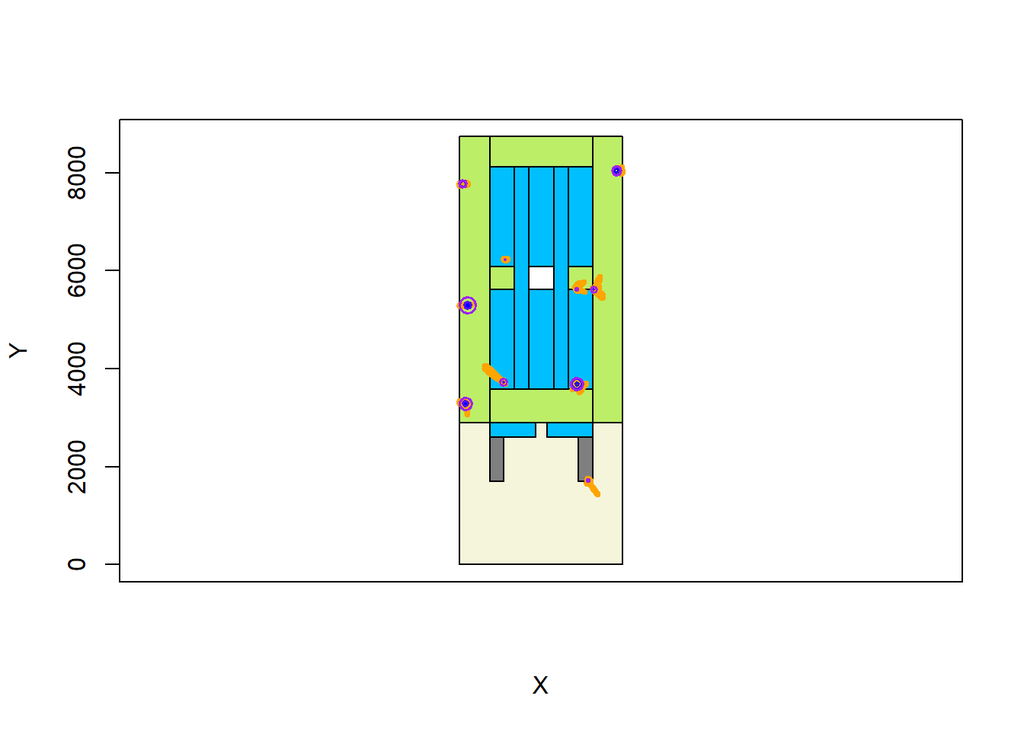

```r
stillTags.stats=stats.still(AniObj=df,NIDs=c(1:10), percentile=c(0.90,0.95,0.99),graphs=TRUE)
```

The `mean_error` column represents the average distance to the centroid of all recorded positions. The quantiles represent the minimum distance from the tag that encompasses at least 90%, 95% or 99% of positions relative to the centroid.

```r
head(stillTags.stats$stats)
```

```
##   NIDs     IDs npositions     cent_x   cent_y mean_error       q9      q95       q99
## 1    1 2203669      72122 2741.31266 5621.338   7.809932 11.33613 14.67824  70.62550
## 2    2 2225414      39097 2640.10234 1719.523   7.477889 13.28103 17.07083  30.17836
## 3    3 2225426      75150  906.99488 3724.979   8.379526 10.17809 14.19939  75.87451
## 4    4 2225534      74715  172.96579 5295.752  19.532250 32.31460 75.11627 167.25036
## 5    5 2225549      76960 2402.32766 5624.875   8.413396 16.10204 22.05250  33.88988
## 6    6 2225588      75720   65.86815 7786.889  34.259556 67.53004 69.66067  87.17975
```

## Filtering data

Using the function `filterAniSpace()` allows us to filter the `AniSpace` object using the identification of individuals, specific time ranges and/or certain areas.

```r
df.ID.filt=filterAniSpace(AniObj=df,NIDs=c(12:16,18))
```

```
## - Filtering: 6 individual(s) from the AniSpace object.
```

Let’s see how many individuals are now in the object:

```r
df.ID.filt
```

```
## -------AniSpace: Spatio-temporal object-------
## # Individuals: 6 ( 2417161, 2417169, 2417171, 2417175, 2417195 ,...)
## # Traits: 5 ( Date, Parity, DIM, Breed, Disease )
## # Areas: 19 ( 0, 1, 2, 3, 4 ,...)
## # Positions per ID: mean= 63017.5 ; sd= 8533.98
## % missing positions (Time resolution= 1 sec ): 27.06 %
##   Position bounds: x=c( 0 , 3340 ); y=c( 0 , 8738 )
##   Time span: 1602806400 ( 2020-10-16 ) - 1602892800 ( 2020-10-17 )
##   Durantion: 1.0 day(s)
```

```r
Tmin=as.numeric(as.POSIXct("2020-10-16 11:00:00", format = "%Y-%m-%d %H:%M:%S", tz = "UTC"))
Tmax=as.numeric(as.POSIXct("2020-10-16 11:59:59", format = "%Y-%m-%d %H:%M:%S", tz = "UTC"))
df.Time.filt=filterAniSpace(AniObj=df, TimeWindow=c(Tmin,Tmax))
```

```
## - Filtering Time: 1602846000 (2020-10-16 11:00:00) - 1602849599 (2020-10-16 11:59:59) from the AniSpace object.
```

Let’s see what the Time span is in our object after filtering:

```r
df.Time.filt
```

```
## -------AniSpace: Spatio-temporal object-------
## # Individuals: 20 ( 2203669, 2225414, 2225426, 2225534, 2225549 ,...)
## # Traits: 5 ( Date, Parity, DIM, Breed, Disease )
## # Areas: 19 ( 0, 1, 2, 3, 4 ,...)
## # Positions per ID: mean= 2610.75 ; sd= 876.26
## % missing positions (Time resolution= 1 sec ): 27.46 %
##   Position bounds: x=c( 0 , 3340 ); y=c( 0 , 8738 )
##   Time span: 1602846000 ( 2020-10-16 11:00:00 ) - 1602849599 ( 2020-10-16 11:59:59 )
##   Durantion: 60.0 min
```

Lastly, we will filter areas:

```r
df.Area.filt=filterAniSpace(AniObj=df,Area=as.character(10))
```

```
## - Filtering: 1 area(s) from the AniSpace object.
```

```
## - Filtering: 18 individual(s) had no position information after filtering.
```

Let’s see how many areas are now in the object:

```r
df.Area.filt
```

```
## -------AniSpace: Spatio-temporal object-------
## # Individuals: 2 ( 2417161, 2417272 )
## # Traits: 5 ( Date, Parity, DIM, Breed, Disease )
## # Areas: 19 ( 0, 1, 2, 3, 4 ,...)
## # Positions per ID: mean= 29105 ; sd= 20496.2
## % missing positions (Time resolution= 1 sec ): 66.31 %
##   Position bounds: x=c( 0 , 3340 ); y=c( 0 , 8738 )
##   Time span: 1602806400 ( 2020-10-16 ) - 1602892800 ( 2020-10-17 )
##   Durantion: 1.0 day(s)
```

Let’s check whether the filtering works by plotting the position of one of the individuals:

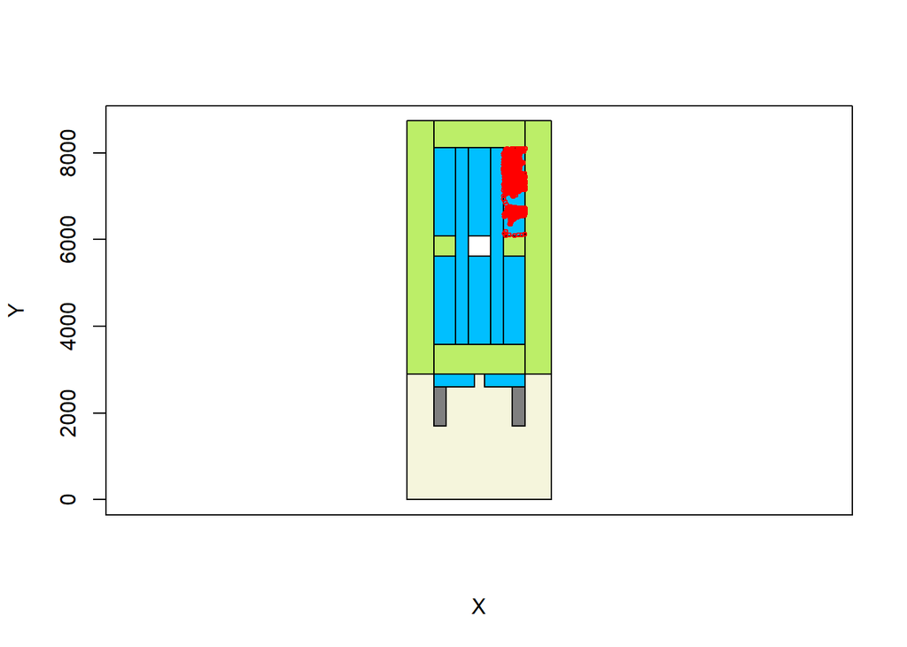

```r
plotAniSpace(df.Area.filt,IDs="2417161")
```

When filtering the `AniSpace` object using the function `filterAniSpace()` we can consider an extension of the borders of the areas by using the option `soft.boundaries`:

```r
df.Area.filt2=filterAniSpace(AniObj=df,Area=as.character(10), soft.boundaries = 200)
```

```
## - Filtering: 1 area(s) from the AniSpace object.
```

```
## - Filtering: 18 individual(s) had no position information after filtering.
```

Let’s check if the area occupied increased after using the option `soft.boundaries`:

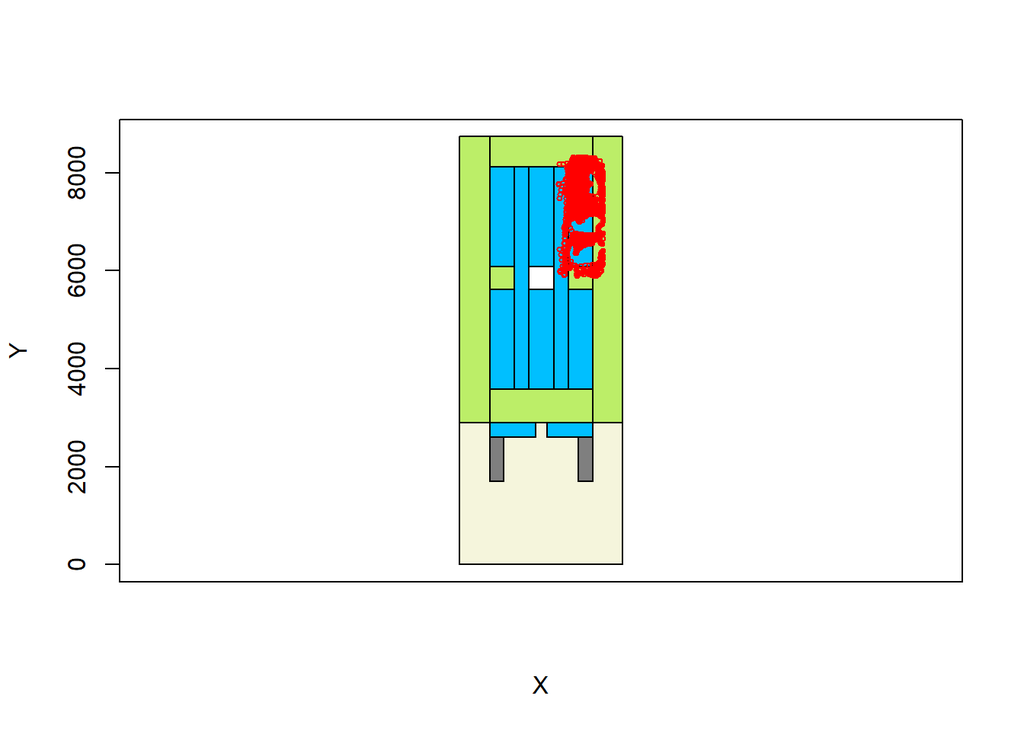

```r
plotAniSpace(df.Area.filt2,IDs="2417161")
```

We used this option in various scientific studies to keep track of the cows’ positions when they put their heads through the rails. When feeding, the tags could legitimately be found outside the pen area. Therefore, we extended the boundaries by 50 cm in all directions (See [Marina et al., 2024](https://doi.org/10.1016/J.APPLANIM.2024.106366)).

## Interpolation

Due to the missing data, interpolation is a necessary step before this information can be analysed. The interpolation method complete missing positions using different methods (`linear`,`spline`, or `makima`). In this case, we will apply the Modified Akima interpolation method following [Ren et al., 2022](https://doi.org/10.3389/fanim.2022.896666).

```r
df.inter=interpolate.AniSpace(AniObj=df.ID.filt, method="makima", tails=TRUE)
```

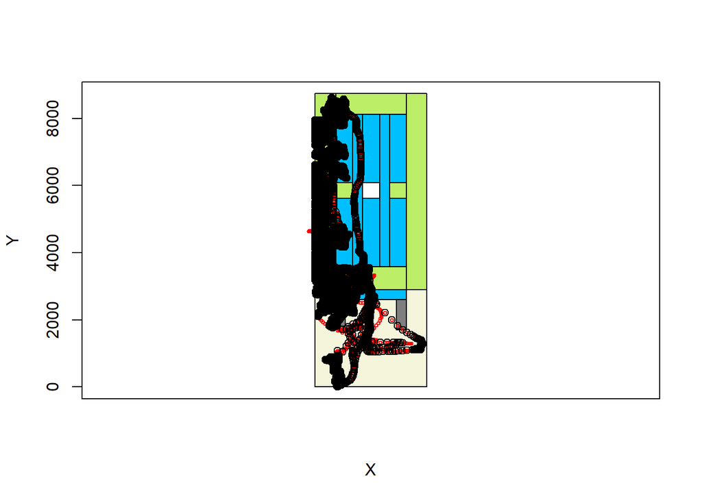

```r
plotAniSpace(df.inter,NIDs=2)
Inter=df.inter@Pos[[2]]$Inter
points(df.inter@Pos[[2]]$x[!Inter],df.inter@Pos[[2]]$y[!Inter],col="black" )
```

The spikes found beyond the designated group area prove the necessity of pre-processing this data by filtering the spikes registered by the system using the function `filter.spikes()` and clustering the positions to smooth the animals’ walking paths using the function `cluster.AniSpace()`. However, these functions are not available for this vignette.

## Movement analysis

The function `movement.AniSpace` estimates the distance walked, speed and the turning angles per individual, and performs a cluster analysis of the areas included in the `AniObj` object to classify different behaviours. If the functions incorporates the option `k.means==TRUE`, it will perform a K-means cluster analysis. This uses the speed and turning angle information from all individuals in the `AniObj` to assign `k.mov` behaviours to the different areas detailed in the object.

```r
df.mov=movement.AniSpace(AniObj=df.ID.filt)
```

The output object reports the time interval between positions, the distance walked between registers and the speed, as well as the turning angle.

```r
head(df.mov)
```

```
##   NIDs     IDs Time    x    y Time_interval walked_dist    speed Turn_angle
## 3    1 2417161    2 2429 7191             1    13.34166 13.34166   335.1196
## 4    1 2417161    3 2419 7190             1    10.04988 10.04988   352.7160
## 5    1 2417161    4 2412 7200             1    12.20656 12.20656   299.2814
## 6    1 2417161    5 2405 7216             1    17.46425 17.46425   348.6374
## 7    1 2417161    6 2402 7232             1    16.27882 16.27882   346.9903
## 8    1 2417161    7 2400 7244             1    12.16553 12.16553   358.8427
```

Create a circular histogram depicting the turning angles:

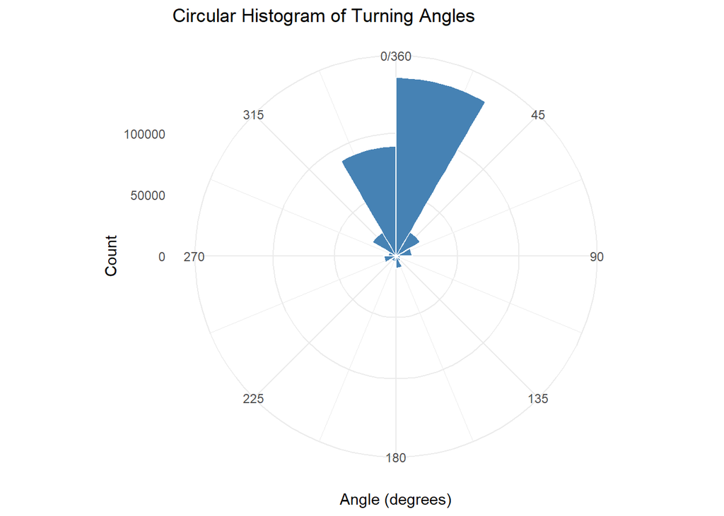

```r
library(ggplot2)
ggplot(df.mov, aes(x = Turn_angle)) +
  geom_histogram(binwidth = 30, fill = "steelblue", color = "white", boundary = 0) +
  coord_polar(start = 0, direction = 1) +
  scale_x_continuous(limits = c(0, 360), breaks = seq(0, 360, by = 45)) +
  labs(x = "Angle (degrees)", y = "Count",
       title = "Circular Histogram of Turning Angles") +
  theme_minimal()
```

## Social networks

Lastly, we will run the function `spatialint.AniSpace()` to estimate the pairwise spatial interactions between individuals included in the object. The function will return an adjacency matrix based on the chosen proximity method. (`time` or `nint`). `time` will export the duration spent by each pair of animals that are closer to each other than the specified `dist.thr` threshold. `nint` will record the number of instances where each pair of animals got within the specified `dist.thr` threshold of each other.

```r
AdjMat.obj=spatialint.AniSpace(AniObj=df.ID.filt)
```

The adjacency matrix shows how many seconds each pair of individuals spent within 2.5 metres of each other (See default parameters of `spatialint.AniSpace()`)

```r
AdjMat.obj
```

```
##       1     2     3     4     5     7
## 1 56270     0     0     0     0   139
## 2     0 67774   113   953  8010     0
## 3     0   113 68661   153  1149     0
## 4     0   953   153 62013    87     0
## 5     0  8010  1149    87 73086     0
## 7   139     0     0     0     0 50298
```

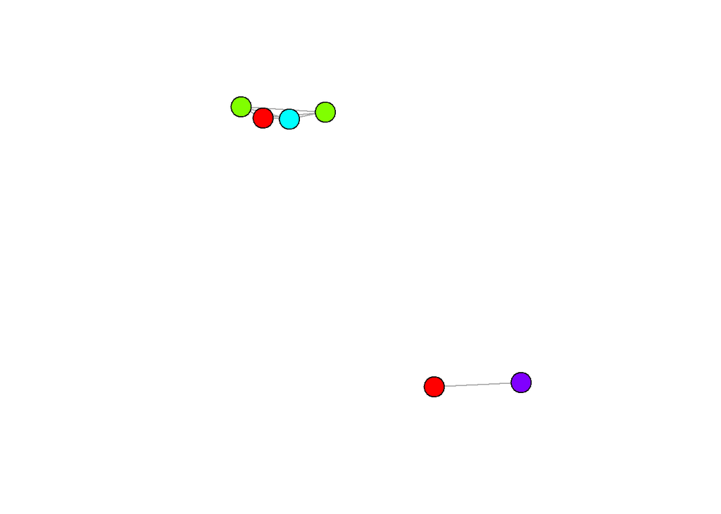

```r
library(igraph)
AdjMat.obj.bin=ifelse(AdjMat.obj>600,1,0)

grp=as.character(df.ID.filt@Info$Parity)
pal=setNames(rainbow(length(unique(grp))), unique(grp))

g=graph_from_adjacency_matrix(AdjMat.obj, mode = "undirected", diag = FALSE, weighted = TRUE)
plot(g,vertex.color = pal[grp], vertex.label = NA)
```

#### Recommended literature

- Hansson, I., Silvera, A., Ren, K., Woudstra, S., Skarin, A., Fikse, W. F., Nielsen, P. P., & Rönnegård, L. (2023). [Cow characteristics associated with the variation in number of contacts between dairy cows](https://doi.org/10.3168/JDS.2022-21915). Journal of Dairy Science.
- Ren, K., Alam, M., Nielsen, P. P., Gussmann, M. K., & Rönnegård, L. (2022). [Interpolation methods to improve data quality of indoor positioning data for dairy cattle](https://doi.org/10.3389/FANIM.2022.896666). Frontiers in Animal Science.
- Ren, K., Nielsen, P. P., Alam, M., & Rönnegård, L. (2021). [Where do we find missing data in a commercial real-time location system? Evidence from 2 dairy farms](https://doi.org/10.3168/JDSC.2020-0064). JDS Communications.
- Churakov, M., Silvera, A. M., Gussmann, M., & Nielsen, P. P. (2021). [Parity and days in milk affect cubicle occupancy in dairy cows](https://doi.org/10.1016/J.APPLANIM.2021.105494). Applied Animal Behaviour Science.
- Marina, H., Ren, K., Hansson, I., Fikse, F., Nielsen, P.P. & Rönnegård, L. (2024). [New insight into social relationships in dairy cows and how time of birth, parity, and relatedness affect spatial interactions later in life](https://doi.org/10.3168/JDS.2023-23483). Journal of Dairy Science.
- Marina, H., Nielsen, P.P., Fikse, W.F. & Rönnegård, L. (2024). [Multiple factors shape social contacts in dairy cows](https://doi.org/10.1016/J.APPLANIM.2024.106366). Applied Animal Behaviour Science.
- Marina, H., Fikse, W.F. & Rönnegård, L. (2024). [Social network analysis to predict social behavior in dairy cattle](https://doi.org/10.3168/JDSC.2023-0507). JDS Communications.
- Gussmann, M., Marina, H., Ren, K., Rönnegård, L. & Nielsen, P.P. (2025). [Variations in cow behaviour after regrouping in a conventional Swedish dairy herd](https://doi.org/10.1016/J.APPLANIM.2025.106790). Applied Animal Behaviour Science.